# Investigating Homelessness and Rough sleeping – A Data Science Approach (Ptolemy Coburn)

## Investigating Homelessness

```python
import csv as csv
import numpy as np
import pandas as pd
```

## Immersing within the data

In order to become familar with the data on homelessness, provided by data.gov, it is important to do some initial exploritory data analysis.

```python
engdataread = pd.ExcelFile("HomelessnessEngland.xlsx")
engdata = engdataread.parse("Sheet1")
engdata
```

|  | County and local authority area | Number of households 2014-based household interim projections for 2017 (000s) | White | Black or Black British | Asian or Asian British | Mixed | Other ethnic origin | Ethnic Group not Stated | Total | Number per 1,000 households | ... | Total decisions | Bed and breakfast (including shared annexe) | Hostels | LA/HA stock | Private sector leased (by LA or HA) | Other types (including private landlord) | Total in temporary accommodation | Number per 1,000 households.1 | Duty owed but no accommodation has been secured at end of March | Year |
| --- | --- | --- | --- | --- | --- | --- | --- | --- | --- | --- | --- | --- | --- | --- | --- | --- | --- | --- | --- | --- | --- |
| 0 | England | 23464.262 | 35020 | 8050 | 5310 | 2120.0 | 2460 | 3630 | 56580 | 2.410000 | ... | 109410 | 5940 | 5460 | 15710 | 25280 | 27490 | 79880 | 3.400000 | 10000 | 2017-18 |
| 1 | England | 23228.925 | 35880 | 9330 | 5560 | 1990.0 | 2820 | 3510 | 59090 | 2.540000 | ... | 115530 | 6590 | 5740 | 14370 | 24510 | 26020 | 77240 | 3.330000 | 8240 | 2016-17 |
| 2 | England | 22940.025 | 34190 | 9540 | 5480 | 2020.0 | 2770 | 3730 | 57730 | 2.520000 | ... | 114760 | 5960 | 5570 | 13130 | 24420 | 22590 | 71670 | 3.120000 | 6790 | 2015-16 |
| 3 | England | 22718.084 | 33340 | 8670 | 4910 | 1790.0 | 2400 | 3330 | 54430 | 2.395757 | ... | 112330 | 5270 | 5040 | 10920 | 23990 | 19490 | 64710 | 2.848436 | 6900 | 2014-15 |
| 4 | England | 22499.536 | 32770 | 8210 | 4510 | 1670.0 | 2190 | 2950 | 52290 | 2.323870 | ... | 111610 | 4370 | 4880 | 9880 | 25270 | 14010 | 58410 | 2.596231 | 5620 | 2013-14 |
| 5 | England | 22323.000 | 34600 | 8210 | 4180 | 1740.0 | 2270 | 2770 | 53770 | 2.410000 | ... | 113520 | 4510 | 4480 | 9270 | 26260 | 10810 | 55320 | 2.480000 | 5930 | 2012-13 |
| 6 | England | 21731.000 | 33410 | 7130 | 3410 | 1640.0 | 2270 | 2430 | 50290 | 2.310000 | ... | 108720 | 3960 | 4360 | 8270 | 26040 | 7810 | 50430 | 2.320000 | 5400 | 2011-12 |
| 7 | England | 21731.000 | 29540 | 6360 | 2800 | 1330.0 | 1890 | 2240 | 44160 | 2.032120 | ... | 102200 | 2750 | 4250 | 7490 | 26960 | 6790 | 48240 | 2.219972 | 4770 | 2010-11 |
| 8 | England | 21515.000 | 27250 | 5600 | 2620 | 1160.0 | 1550 | 1850 | 40020 | 1.860098 | ... | 89120 | 2050 | 4240 | 7790 | 30920 | 6320 | 51310 | 2.384848 | 3710 | 2009-10 |
| 9 | England | 21514.739 | 37310 | 6630 | 3310 | NaN | 3360 | 2820 | 53430 | 2.483414 | ... | 112900 | 2450 | 5170 | 10480 | 37450 | 8460 | 64000 | 2.974705 | 5560 | 2008-09 |
| 10 | England | 21062.536 | 45500 | 6910 | 3870 | NaN | 3410 | 3520 | 63170 | 2.999164 | ... | 130840 | 3840 | 6450 | 14740 | 40480 | 12000 | 77510 | 3.679994 | 7470 | 2007-08 |
| 11 | England | 21062.000 | 54370 | 7250 | 4130 | NaN | 3730 | 3890 | 73360 | 3.483050 | ... | 159350 | 4310 | 7640 | 18040 | 45600 | 11540 | 87120 | 4.136359 | 8780 | 2006-07 |
| 12 | England | 21109.000 | 69320 | 9960 | 5190 | NaN | 4880 | 4640 | 93980 | 4.500000 | ... | 213290 | 5150 | 9010 | 22350 | 49670 | 10200 | 96370 | 4.565351 | 11010 | 2005-06 |
| 13 | England | 21109.000 | 89180 | 12430 | 6570 | NaN | 6500 | 6170 | 120860 | 5.725520 | ... | 266870 | 6780 | 10280 | 26630 | 46530 | 10860 | 101070 | 4.788005 | 20910 | 2004-05 |

14 rows × 23 columns

```python
engdata.info()
```

```
<class 'pandas.core.frame.DataFrame'>
RangeIndex: 14 entries, 0 to 13
Data columns (total 23 columns):
County and local authority area                                                   14 non-null object
Number of households 2014-based household interim projections for 2017
(000s)     14 non-null float64
White                                                                             14 non-null int64
Black or Black British                                                            14 non-null int64
Asian or Asian British                                                            14 non-null int64
Mixed                                                                             9 non-null float64
Other ethnic origin                                                               14 non-null int64
Ethnic Group not Stated                                                           14 non-null int64
Total                                                                             14 non-null int64
Number per 1,000 households                                                       14 non-null float64
Eligible, homeless and in priority need, but intentionally                        14 non-null int64
Eligible, homeless but not in priority need                                       14 non-null int64
Eligible, but not homeless                                                        14 non-null int64
Total decisions                                                                   14 non-null int64
Bed and breakfast (including shared annexe)                                       14 non-null int64
Hostels                                                                           14 non-null int64
LA/HA stock                                                                       14 non-null int64
Private sector leased (by LA or HA)                                               14 non-null int64
Other types (including private landlord)                                          14 non-null int64
Total in temporary accommodation                                                  14 non-null int64
Number per 1,000 households.1                                                     14 non-null float64
Duty owed but no accommodation has been secured at end of March                   14 non-null int64
Year                                                                              14 non-null object
dtypes: float64(4), int64(17), object(2)
memory usage: 2.6+ KB
```

By Looking at the info of the engdata we can see that we have 14 entries (years), and all but one column shows 14 instances. Mixed race data was only collected for the most recent 9 years, therefore we do not have mixed race data for 2004-05 to 2009.

```python
engdata['mixedWithZeros'] = engdata['Mixed'].fillna(0)
print(engdata['mixedWithZeros'])
```

```
0     2120.0
1     1990.0
2     2020.0
3     1790.0
4     1670.0
5     1740.0
6     1640.0
7     1330.0
8     1160.0
9        0.0
10       0.0
11       0.0
12       0.0
13       0.0
Name: mixedWithZeros, dtype: float64
```

We can simply look at how total homeslessness has changed overtime. The column which shows total homelessness for England is number per 1000 households.

```
Text(0,0.5,'Homeless per 1,000 households')
```

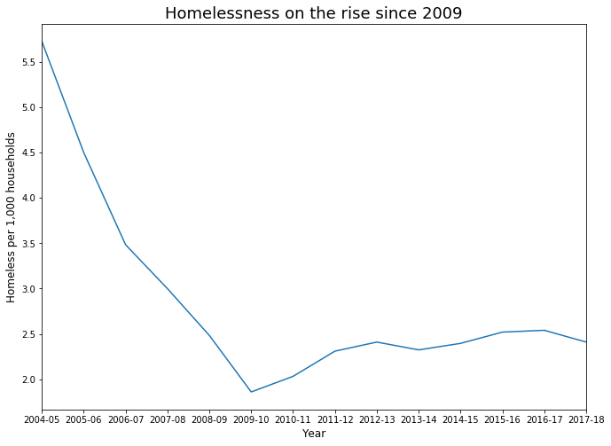

```python
import matplotlib.pyplot as plt
fig = plt.figure(figsize=(11,8))
ax1 = fig.add_subplot(111)

ax1.plot(engdata['Year'],engdata['Number per 1,000 households'])
plt.xlim('2004-05', '2017-18')  #Re-order chart
plt.title('Homelessness on the rise since 2009', size = 18)
plt.xlabel('Year', size = 12)
plt.ylabel('Homeless per 1,000 households', size = 12)
```

Homelessness falls under multiple categories, which contribute to total homeless figures. To investigate each type of homelessness, we can look at a simple timeseries graph.

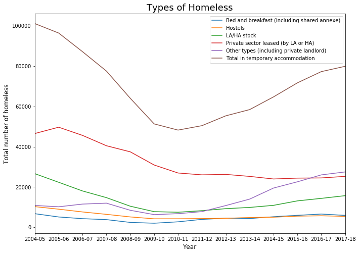

```python
fig = plt.figure(figsize=(11,8))
line_chart2 = plt.plot(engdata['Year'], engdata['Bed and breakfast (including shared annexe)'])
line_chart3 = plt.plot(engdata['Year'], engdata['Hostels'])
line_chart3 = plt.plot(engdata['Year'], engdata['LA/HA stock'])
line_chart3 = plt.plot(engdata['Year'], engdata['Private sector leased (by LA or HA)'])
line_chart3 = plt.plot(engdata['Year'], engdata['Other types (including private landlord)'])
line_chart3 = plt.plot(engdata['Year'], engdata['Total in temporary accommodation'])

plt.xlim('2004-05', '2017-18')  #Re-order chart
plt.title('Types of Homeless', size = 18)
plt.xlabel('Year', size = 12)
plt.ylabel('Total number of homeless', size = 12)
plt.legend(['Bed and breakfast (including shared annexe)','Hostels','LA/HA stock','Private sector leased (by LA or HA)','Other types (including private landlord)','Total in temporary accommodation'], loc=1)
plt.show()
```

We can also investigate how homelessness has changed across each ethic group.

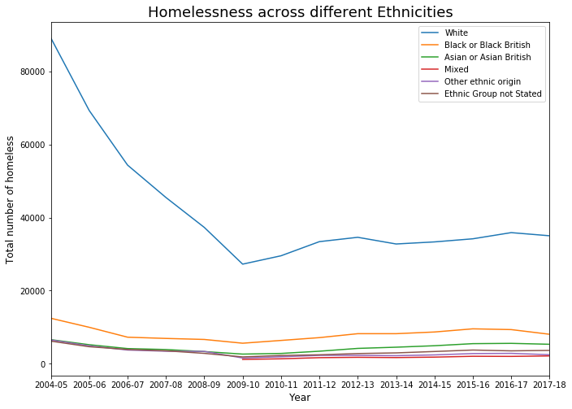

```python
fig = plt.figure(figsize=(11,8))
line_chart2 = plt.plot(engdata['Year'], engdata['White'])
line_chart3 = plt.plot(engdata['Year'], engdata['Black or Black British'])
line_chart3 = plt.plot(engdata['Year'], engdata['Asian or Asian British'])
line_chart3 = plt.plot(engdata['Year'], engdata['Mixed'])
line_chart3 = plt.plot(engdata['Year'], engdata['Other ethnic origin'])
line_chart3 = plt.plot(engdata['Year'], engdata['Ethnic Group not Stated'])

plt.xlim('2004-05', '2017-18')  #Re-order chart
plt.title('Homelessness across different Ethnicities', size = 18)
plt.xlabel('Year', size = 12)
plt.ylabel('Total number of homeless', size = 12)
plt.legend(['White', 'Black or Black British', 'Asian or Asian British', 'Mixed','Other ethnic origin','Ethnic Group not Stated'], loc=1)
plt.show()
```

It's clear from the chart above that the large marjority of the homesless are white, however because of the differing scale it is difficult to assess how other ethic groups have changed. We can normalise the numbers to see how homelessness has changed across ethinicities.

We can iterate over column and normalize only numeric values.

Normalisation will produce values [0 - 1].

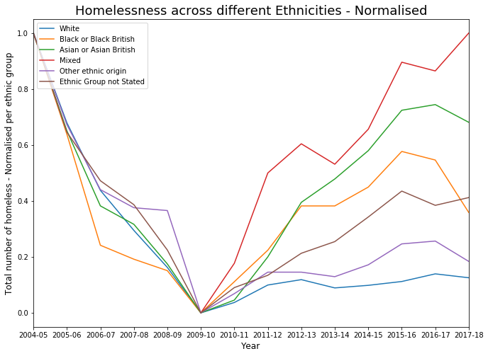

```python
for i, col in engdata.iteritems():

    if not isinstance(col[0],str):
        minVal = col.min()
        maxVal = col.max()
        normCol = (col - minVal) / (maxVal - minVal)
        engdata[[i]] = normCol

## We can now plot ethinicities on a normalised scale:

fig = plt.figure(figsize=(11,8))

line_chart2 = plt.plot(engdata['Year'], engdata['White'])
line_chart3 = plt.plot(engdata['Year'], engdata['Black or Black British'])
line_chart3 = plt.plot(engdata['Year'], engdata['Asian or Asian British'])
line_chart3 = plt.plot(engdata['Year'], engdata['Mixed'])
line_chart3 = plt.plot(engdata['Year'], engdata['Other ethnic origin'])
line_chart3 = plt.plot(engdata['Year'], engdata['Ethnic Group not Stated'])

plt.xlim('2004-05', '2017-18')  #Re-order chart
plt.title('Homelessness across different Ethnicities - Normalised', size = 18)
plt.xlabel('Year', size = 12)
plt.ylabel('Total number of homeless - Normalised per ethnic group', size = 12)
plt.legend(['White', 'Black or Black British', 'Asian or Asian British', 'Mixed','Other ethnic origin','Ethnic Group not Stated'], loc=2)
plt.show()
```

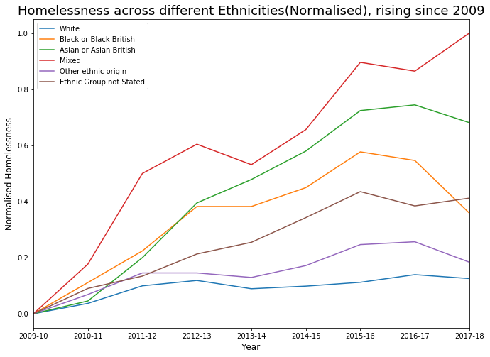

```python
fig = plt.figure(figsize=(11,8))

line_chart2 = plt.plot(engdata['Year'], engdata['White'])
line_chart3 = plt.plot(engdata['Year'], engdata['Black or Black British'])
line_chart3 = plt.plot(engdata['Year'], engdata['Asian or Asian British'])
line_chart3 = plt.plot(engdata['Year'], engdata['Mixed'])
line_chart3 = plt.plot(engdata['Year'], engdata['Other ethnic origin'])
line_chart3 = plt.plot(engdata['Year'], engdata['Ethnic Group not Stated'])

plt.xlim('2009-10', '2017-18')  #Re-order chart
plt.title('Homelessness across different Ethnicities(Normalised), rising since 2009', size = 18)
plt.xlabel('Year', size = 12)
plt.ylabel('Normalised Homelessness', size = 12)
plt.legend(['White', 'Black or Black British', 'Asian or Asian British', 'Mixed','Other ethnic origin','Ethnic Group not Stated'], loc=2)
plt.show()
```

We can see that the number of Mixed and Asian or Asian British homeless are rising at the highest rate, relative to the number of homeless in each subset.

## Rough Sleeping

Rough sleeping numbers are also available from data.gov. We can see the number of roughsleepers nationally and locally.

```python
data = pd.ExcelFile("roughsleeping.xlsx")
roughsleep = data.parse("Sheet1")
print(roughsleep.head())
```

```
    ONS code Local authority / Region       Unnamed: 2  2010  2011  2012  \
0  E07000005                 Chiltern       South East     0     0     2
1  E07000118                  Chorley       North West     2     0     0
2  E07000048             Christchurch       South West     0     0     8
3  E09000001           City of London           London    20    18    21
4  E07000071               Colchester  East of England    10    24    25

   2013  2014  2015  2016  2017  Number of households 2017 ('000)2  \
0     4     3     1     1     1                             38.113
1     1     0     1     0     0                             48.880
2     1     2     8    10     5                             22.477
3    35    50    48    50    36                              5.084
4    35     2     9    20    20                             77.744

   2017 rough sleeping rate (per 1,000 households)
0                                         0.026238
1                                         0.000000
2                                         0.222450
3                                         7.081039
4                                         0.257255
```

```python
roughsleep.info()
```

```
<class 'pandas.core.frame.DataFrame'>
RangeIndex: 269 entries, 0 to 268
Data columns (total 13 columns):
ONS code                                           269 non-null object
Local authority / Region                           269 non-null object
Unnamed: 2                                         269 non-null object
2010                                               269 non-null int64
2011                                               269 non-null int64
2012                                               269 non-null int64
2013                                               269 non-null int64
2014                                               269 non-null int64
2015                                               269 non-null int64
2016                                               269 non-null int64
2017                                               269 non-null int64
Number of households 2017 ('000)2                  269 non-null float64
2017 rough sleeping rate (per 1,000 households)    269 non-null float64
dtypes: float64(2), int64(8), object(3)
memory usage: 27.4+ KB
```

```python
data1 = pd.ExcelFile("roughsleeping.xlsx")
roughsleeptotal = data.parse("table 1")
print(roughsleeptotal.head())
```

```
  Table 1: Street counts and estimates of rough sleeping, by local authority district and region  \
0                       England, Autumn1 2010 - 2017
1                                                NaN
2                                           ONS code
3                                                NaN
4                                          E92000001

                 Unnamed: 1 Unnamed: 2 Unnamed: 3  Unnamed: 4  Unnamed: 5  \
0                       NaN        NaN        NaN         NaN         NaN
1                       NaN        NaN        NaN         NaN         NaN
2  Local authority / Region        NaN       2010      2011.0      2012.0
3                       NaN        NaN        NaN         NaN         NaN
4                   England        NaN       1768      2181.0      2309.0

   Unnamed: 6  Unnamed: 7  Unnamed: 8  Unnamed: 9  Unnamed: 10  \
```

[output cut: 19 more lines]

```python
## We only want the 6th row of this table as it has the total rough sleep count for England:

select = roughsleeptotal.iloc[4,3:11]
engroughsleep = np.asarray(select)
print(engroughsleep)
```

```
[1768 2181.0 2309.0 2414.0 2744.0 3569.0 4134.0 4751.0]
```

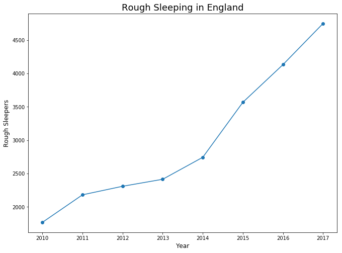

```python
## This array shows the total number of rough sleepers in the UK from 2010 to 2017

fig = plt.figure(figsize=(11,8))

year = np.array([2010,2011,2012,2013,2014,2015,2016,2017])

line_chart1 = plt.plot(year,engroughsleep, marker = 'o')
plt.title('Rough Sleeping in England', size = 18)
plt.xlabel('Year', size = 12)
plt.ylabel('Rough Sleepers', size = 12)
plt.show()
```

We have ascertained that rough sleeping has risen in England, but we can investigate how rough sleeping has changed across the country.

```python
## Add column title to Region Column

roughsleep = roughsleep.rename(columns = {'Unnamed: 2': 'Region'})
```

```
Text(0,0.5,'2017 rough sleeping rate (per 1,000 households)')
```

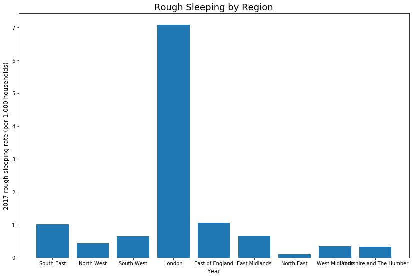

```python
fig = plt.figure(figsize=(14,9))
plt.bar(roughsleep['Region'], roughsleep['2017 rough sleeping rate (per 1,000 households)'])
plt.title('Rough Sleeping by Region', size = 18)
plt.xlabel('Year', size = 12)
plt.ylabel('2017 rough sleeping rate (per 1,000 households)', size = 12)
```

```python
## In order to investigate each region we need to make a long version of the table

data = roughsleep.iloc[:,1:11]
melt = data.melt(id_vars = ['Local authority / Region', 'Region'], var_name = 'Year')
melt.sort_values(by=['value'], ascending = False)
londonroughsleep = melt[melt['Region'] == 'London']
londonroughsleep.sort_values(by=['value'], ascending = False)
```

|  | Local authority / Region | Region | Year | value |
| --- | --- | --- | --- | --- |
| 1597 | Westminster | London | 2015 | 265 |
| 1328 | Westminster | London | 2014 | 265 |
| 1866 | Westminster | London | 2016 | 260 |
| 2135 | Westminster | London | 2017 | 217 |
| 1059 | Westminster | London | 2013 | 140 |
| 790 | Westminster | London | 2012 | 131 |
| 252 | Westminster | London | 2010 | 128 |
| 521 | Westminster | London | 2011 | 106 |
| 2001 | Newham | London | 2017 | 76 |
| 1627 | Croydon | London | 2016 | 68 |
| 2030 | Redbridge | London | 2017 | 65 |
| 1906 | Ealing | London | 2017 | 62 |
| 1761 | Redbridge | London | 2016 | 60 |
| 656 | Newham | London | 2012 | 55 |
| 1358 | Croydon | London | 2015 | 51 |
| 1617 | City of London | London | 2016 | 50 |
| 1079 | City of London | London | 2014 | 50 |
| 1348 | City of London | London | 2015 | 48 |
| 1849 | Waltham Forest | London | 2016 | 47 |
| 344 | Hounslow | London | 2011 | 45 |
| 1148 | Hillingdon | London | 2014 | 45 |
| 2118 | Waltham Forest | London | 2017 | 44 |
| 2077 | Southwark | London | 2017 | 44 |
| 632 | Lewisham | London | 2012 | 43 |
| 1492 | Redbridge | London | 2015 | 43 |
| 1943 | Haringey | London | 2017 | 43 |
| 1732 | Newham | London | 2016 | 41 |
| 879 | Hillingdon | London | 2013 | 38 |
| 1955 | Hillingdon | London | 2017 | 36 |
| 1886 | City of London | London | 2017 | 36 |
| ... | ... | ... | ... | ... |
| 37 | Enfield | London | 2010 | 5 |
| 23 | Ealing | London | 2010 | 5 |
| 1403 | Hammersmith and Fulham | London | 2015 | 5 |
| 1941 | Hammersmith and Fulham | London | 2017 | 5 |
| 504 | Waltham Forest | London | 2011 | 4 |
| 479 | Sutton | London | 2011 | 4 |
| 575 | Enfield | London | 2012 | 4 |
| 1139 | Harrow | London | 2014 | 4 |
| 68 | Havering | London | 2010 | 4 |
| 748 | Sutton | London | 2012 | 4 |
| 870 | Harrow | London | 2013 | 4 |
| 13 | Croydon | London | 2010 | 4 |
| 1035 | Tower Hamlets | London | 2013 | 4 |
| 63 | Harrow | London | 2010 | 4 |
| 606 | Havering | London | 2012 | 3 |
| 81 | Islington | London | 2010 | 3 |
| 2093 | Sutton | London | 2017 | 3 |
| 306 | Enfield | London | 2011 | 3 |
| 337 | Havering | London | 2011 | 3 |
| 1042 | Waltham Forest | London | 2013 | 3 |
| 235 | Waltham Forest | London | 2010 | 2 |
| 601 | Harrow | London | 2012 | 2 |
| 376 | Merton | London | 2011 | 2 |
| 875 | Havering | London | 2013 | 2 |
| 53 | Greenwich | London | 2010 | 2 |
| 1136 | Haringey | London | 2014 | 1 |
| 860 | Greenwich | London | 2013 | 1 |
| 332 | Harrow | London | 2011 | 1 |
| 1017 | Sutton | London | 2013 | 0 |
| 210 | Sutton | London | 2010 | 0 |

216 rows × 4 columns

To effectively visualise the change in number of rough sleepers over the last 7 years we can use a grid plot which shows each borough on it's own axis.

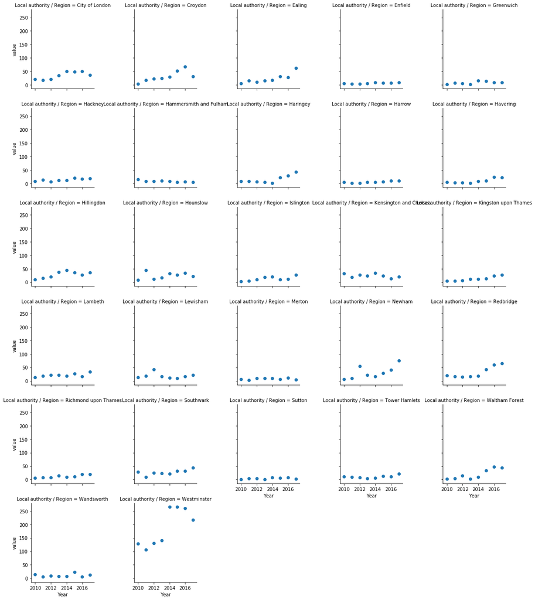

```python
import seaborn as sns

g = sns.FacetGrid(londonroughsleep, col="Local authority / Region", col_wrap = 5)
g = (g.map(plt.scatter, "Year", "value").add_legend())
```

It is clear that each region has differing levels of roughsleeping, and the level of roughsleeping in each borough is changing differently overtime.

To better understand why different boroughs have differently levels of homelessness, we can load some contextual data, from the London data store.

```python
dataimport = pd.ExcelFile("london-borough-profiles.xlsx")
profiles = dataimport.parse("Data")
profiles_london = profiles.iloc[:33,:]
profiles_london.head()
```

|  | Code | New code | Area name | Inner/ Outer London | GLA Population Estimate 2017 | GLA Household Estimate 2017 | Inland Area (Hectares) | Population density (per hectare) 2017 | Average Age, 2017 | Proportion of population aged 0-15, 2015 | ... | Happiness score 2011-14 (out of 10) | Anxiety score 2011-14 (out of 10) | Childhood Obesity Prevalance (%) 2015/16 | People aged 17+ with diabetes (%) | Mortality rate from causes considered preventable 2012/14 | Political control in council | Proportion of seats won by Conservatives in 2014 election | Proportion of seats won by Labour in 2014 election | Proportion of seats won by Lib Dems in 2014 election | Turnout at 2014 local elections |
| --- | --- | --- | --- | --- | --- | --- | --- | --- | --- | --- | --- | --- | --- | --- | --- | --- | --- | --- | --- | --- | --- |
| 0 | E09000001 | E09000001 | City of London | Inner London | 8800 | 5325.82 | 290.393 | 30.3037 | 43.2 | 11.4 | ... | 5.99 | 5.57 | NaN | 2.637945 | 128.833 | . | . | . | . | . |
| 1 | E09000002 | E09000002 | Barking and Dagenham | Outer London | 209000 | 78188.4 | 3610.78 | 57.8822 | 32.9 | 27.2 | ... | 7.05 | 3.05 | 28.542 | 7.272108 | 227.605 | Lab | 0 | 100 | 0 | 36.4974 |
| 2 | E09000003 | E09000003 | Barnet | Outer London | 389600 | 151423 | 8674.83 | 44.9115 | 37.3 | 21.1 | ... | 7.37 | 2.75 | 20.6579 | 6.026084 | 133.77 | Cons | 50.7937 | . | 1.5873 | 40.481 |
| 3 | E09000004 | E09000004 | Bexley | Outer London | 244300 | 97735.8 | 6058.07 | 40.3264 | 39.0 | 20.6 | ... | 7.21 | 3.29 | 22.7093 | 6.859383 | 164.286 | Cons | 71.4286 | 23.8095 | 0 | 39.6308 |
| 4 | E09000005 | E09000005 | Brent | Outer London | 332100 | 121048 | 4323.26 | 76.817 | 35.6 | 20.9 | ... | 7.22 | 2.92 | 24.3444 | 7.920348 | 169.356 | Lab | 9.52381 | 88.8889 | 1.5873 | 36.272 |

5 rows × 85 columns

We can hypothesise that total population and total number of roughsleepers are correlated:

```python
londonroughsleep2017 = londonroughsleep[londonroughsleep['Year'] == 2017]
```

```python
boroughpop = profiles.iloc[:,2:5]
boroughpop.rename(columns={'Area name' : 'Local authority / Region'}, inplace = True)
joined = londonroughsleep2017.merge(boroughpop, on='Local authority / Region', how='left')
joined.head()
```

|  | Local authority / Region | Region | Year | value | Inner/ Outer London | GLA Population Estimate 2017 |
| --- | --- | --- | --- | --- | --- | --- |
| 0 | City of London | London | 2017 | 36 | Inner London | 8800 |
| 1 | Croydon | London | 2017 | 31 | Outer London | 386500 |
| 2 | Ealing | London | 2017 | 62 | Outer London | 351600 |
| 3 | Enfield | London | 2017 | 9 | Outer London | 333000 |
| 4 | Greenwich | London | 2017 | 8 | Outer London | 280100 |

We know that the number of roughsleepers varies dramatically in each borough, from looking at the facet plot. Westminster has by far the highest level of roughsleepers.

To assess the relationship between roughsleepers and population, we need to make sure we have no outliers.

By plotting with Bokeh, we can add an interactive hover-over.

```python
# Import figure from bokeh.plotting
from bokeh.plotting import figure, output_file, show, ColumnDataSource

from bokeh.models import HoverTool

# Import output_file and show from bokeh.io
from bokeh.io import output_file, show

source = ColumnDataSource(joined)

# Create the figure: p
p = figure(x_axis_label='Total Population',y_axis_label ='Rough Sleepers',title="Rough Sleepers and Total Population",
           plot_width=400, plot_height=400)

hover = HoverTool()

hover.tooltips = [
    ("Borough", "@{Local authority / Region}"),
    ("Population", "@{GLA Population Estimate 2017}"),
    ("Rough", "@value")]

p.tools.append(hover)


# Add a circle glyph to the figure p
p.circle(x='GLA Population Estimate 2017', y='value',source=source)

# Call the output_file() function and specify the name of the file
output_file('roughsleep&population.html')


# Display the plot
show(p)
```

However, rather than just removing these outliers, we can perform a more robust method for removing outliers.

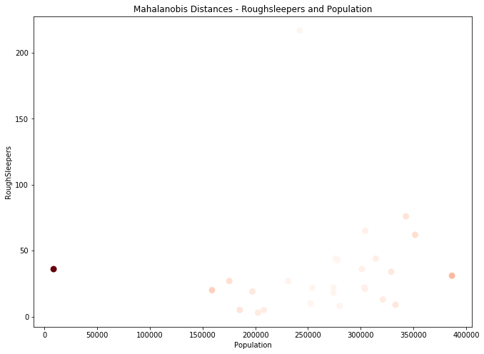

```python
columnValues = joined.as_matrix(["GLA Population Estimate 2017","value"])

meanValue = joined['value'].mean()
meanPop = joined['GLA Population Estimate 2017'].mean()


meanVector = np.asarray([meanValue, meanPop ]).reshape(1,2)

from scipy import spatial

mahalanobisDistances = spatial.distance.cdist(columnValues, meanVector, 'mahalanobis')[:,0]

# We create a new figure where we use a color mapping and use the computed mahalanobis distances
# as the mapping value

fig = plt.figure(figsize=(11,8))
plt.xlabel('Population')
plt.title('Mahalanobis Distances - Roughsleepers and Population')
plt.ylabel('RoughSleepers')
plt.scatter(joined['GLA Population Estimate 2017'],joined['value'] , c = mahalanobisDistances, cmap = plt.cm.Reds, s = 80, linewidth= 0)
```

## Simple Correlation/Regression Analysis to predict roughsleepers in London

```python
filteredjoined =  joined[(joined['Local authority / Region'] != 'City of London')]
x = filteredjoined.iloc[:,5]
y = filteredjoined.iloc[:,3]
import scipy as scipy
from scipy import stats
```

```python
scipy.stats.pearsonr(x,y)
```

```
(0.133245893692287, 0.5163952331940059)
```

```python
scipy.stats.spearmanr(x,y)
```

```
SpearmanrResult(correlation=0.41690942120884944, pvalue=0.034103716392532755)
```

We can see that the Pearson's correlation shows a negligible relationship between Population and number of roughsleepers. However, the Spearman's rank correlation shows a much stronger, positive relationship. This is likely because Spearman's rank correlation is a nonparametric measure and is thus more resistant to outliers.

To test this, we can selectively remove Westminster, and rerun the correlations.

```python
selectivefilter = joined[(joined['Local authority / Region'] != 'Westminster') & (joined['Local authority / Region'] != 'City of London')]
```

```python
x1 = selectivefilter['GLA Population Estimate 2017']
y1 = selectivefilter['value']
```

```python
scipy.stats.pearsonr(x1,y1)
```

```
(0.49925603325626944, 0.011060548534641404)
```

```python
scipy.stats.spearmanr(x1,y1)
```

```
SpearmanrResult(correlation=0.4972082314220188, pvalue=0.01144802425080715)
```

```python
scipy.stats.linregress(x1,y1)
```

```
LinregressResult(slope=0.00016204426978429714, intercept=-16.88947861927146, rvalue=0.49925603325626944, pvalue=0.01106054853464141, stderr=5.863976261974346e-05)
```

```python
slope, intercept, r_value, p_value, std_err = scipy.stats.linregress(x1, y1)
```

```python
print("r-squared:", r_value**2)
```

```
r-squared: 0.24925658674278522
```

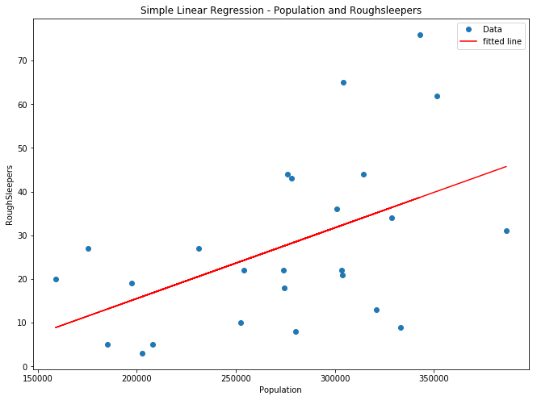

```python
fig = plt.figure(figsize=(11,8))
plt.xlabel('Population')
plt.title('Simple Linear Regression - Population and Roughsleepers')
plt.ylabel('RoughSleepers')
plt.plot(x1,y1,'o',label='Data')
plt.plot(x1, intercept + slope*x1, 'r', label='fitted line')
plt.legend()
plt.show()
```

As we can see from the rsquared value and the graphical representation of the of the regressor, there is a weak relationship between population and roughsleepers. However, there is still some predictive power to assess the number of roughsleepers based upon population. The difficulty is the assumption that a person that ends up on the street is in a given London borough in which they are unable to get a home because of the population size. It is likely that rough sleepers will move around London to where they have the best support network, access to ammendities or for social reasons. Without a better contextual understanding of how and why homeless people are situated in a borough of London, it is difficult to assess the predictive power of this simple linear model.

To assess the validity of the model, statsmodels offers a more indepth breakdown of the model:

```python
import statsmodels.api as sm
model = sm.OLS(y1,x1)
results = model.fit()
results.summary()
```

OLS Regression Results

| Dep. Variable: | value | R-squared: | 0.745 |
| --- | --- | --- | --- |
| Model: | OLS | Adj. R-squared: | 0.734 |
| Method: | Least Squares | F-statistic: | 70.03 |
| Date: | Sun, 16 Dec 2018 | Prob (F-statistic): | 1.41e-08 |
| Time: | 11:20:57 | Log-Likelihood: | -106.12 |
| No. Observations: | 25 | AIC: | 214.2 |
| Df Residuals: | 24 | BIC: | 215.5 |
| Df Model: | 1 |  |  |
| Covariance Type: | nonrobust |  |  |

|  | coef | std err | t | P>\|t\| | [0.025 | 0.975] |
| --- | --- | --- | --- | --- | --- | --- |
| GLA Population Estimate 2017 | 0.0001 | 1.23e-05 | 8.368 | 0.000 | 7.76e-05 | 0.000 |

| Omnibus: | 3.402 | Durbin-Watson: | 1.958 |
| --- | --- | --- | --- |
| Prob(Omnibus): | 0.183 | Jarque-Bera (JB): | 2.529 |
| Skew: | 0.778 | Prob(JB): | 0.282 |
| Kurtosis: | 2.933 | Cond. No. | 1.00 |

Warnings:  
[1] Standard Errors assume that the covariance matrix of the errors is correctly specified.

It is important to note the differences in values between the r-squared value calculated by the Scipy and Statsmodel models.The difference in the two values is due to the inclusion of the intercept term in the Scipy model. Statsmodels OLS function does not add the intercept by default. Therefore, the Scipy model is more relevent in this context.

Due to the small sample size, evaluating the model using cross fold validation may be ineffective, as the size of the training set and test set would be too small to accurately assess the predictive ability of the model.

## Investigating the change in homelessness in London

The correlation/regression analysis show a positive relationship between the population in a given borough and the number of rough-sleepers. However, as this was just one point in time (2017), we still have limited knowledge on how roughsleepers and homelessness in each borough of London has changed over time.

```python
boroughdataread = pd.ExcelFile("homelessness-borough.xlsx")
boroughdecisions = boroughdataread.parse("Decisions")
print(boroughdecisions.head())
```

```
  Current ONS code             Area name    2004/05   2005/06   2006/07  \
0        E09000001        City of London   7.750000  4.750000  2.400000
1        E09000002  Barking and Dagenham  11.567164  5.149254       NaN
2        E09000003                Barnet   5.614815       NaN  3.595420
3        E09000004                Bexley   4.725275  2.967033  2.758242
4        E09000005                 Brent   6.973684       NaN  7.306931

    2007/08   2008/09   2009/10   2010/11  2011/12  2012/13    2013/14  \
0  2.687570  3.034244  2.000000  2.571429     2.43     3.60   2.607562
1  4.941121  4.523616  3.411765  3.250000     2.93     9.22  11.778189
2  3.234825  2.437868  1.744361  1.832117     2.47     4.28   4.750025
3  2.272478  1.915999  1.391304  2.193548     3.72     3.71   4.461061
4  8.834865  4.742100  3.126214  3.408163     4.93     5.02   6.415320

     2014/15  2015/16  2016/17  2017/18
0   5.715495     6.41     3.60     1.38
1  10.350620    12.50     7.05     6.51
2   4.675447     2.86     4.23     2.88
3   5.237364     5.03     5.18     5.04
4   7.330477     6.05     4.57     4.32
```

"Decisions" is the government term for total number of homeless in a given area. This takes a total number of homeless from each section, such as homeless livnig in BNB's or in temporary accomodation (such as was seen in the initial analysis of homelessness types).

The number of decisions in each year is per 1,000 households, and so is normalised for population in each borough.

```python
#Drop null row and England & London totals
decisions = boroughdecisions.drop(boroughdecisions.index[33:36])
decisions['Area name']
```

```
0             City of London
1       Barking and Dagenham
2                     Barnet
3                     Bexley
4                      Brent
5                    Bromley
6                     Camden
7                    Croydon
8                     Ealing
9                    Enfield
10                 Greenwich
11                   Hackney
12    Hammersmith and Fulham
13                  Haringey
14                    Harrow
```

[output cut: 19 more lines]

```python
# check for missing values:
print (decisions.shape[0] - decisions.count())
```

```
Current ONS code    0
Area name           0
2004/05             0
2005/06             6
2006/07             2
2007/08             2
2008/09             1
2009/10             0
2010/11             0
2011/12             0
2012/13             1
2013/14             0
2014/15             0
2015/16             0
2016/17             0
2017/18             0
dtype: int64
```

```python
# need to replace null values
decisions_with_mean = decisions.fillna(decisions.mean(axis=0))
```

```python
# We can cluster areas based upon the number of decisions made in each year, we don't want to include current ONS code

from numpy.random import rand
from scipy.cluster.vq import kmeans,vq
from sklearn import datasets
import pandas as pd
from sklearn.cluster import KMeans
```

```python
data = decisions_with_mean.as_matrix()
decisionscluster = data[:,2::]
```

```python
#computing K-Means with K = 3 (3 clusters)
kmeansModel = KMeans(init='random', n_clusters=3, n_init=10)
kmeansModel.fit_predict(decisionscluster)
clusterResults = kmeansModel.labels_
clusterResults
```

```
array([0, 2, 0, 0, 1, 0, 0, 2, 0, 2, 1, 1, 0, 1, 0, 0, 0, 1, 1, 2, 0, 1,
       1, 0, 2, 0, 0, 1, 0, 1, 2, 2, 1])
```

```python
decisions_with_mean['Cluster'] = clusterResults.tolist()
```

```python
#Drop first column
decisions_london = decisions_with_mean.iloc[:,1:]
decisionsmelt = decisions_london.melt(id_vars = ['Area name','Cluster'], var_name = 'Year')
```

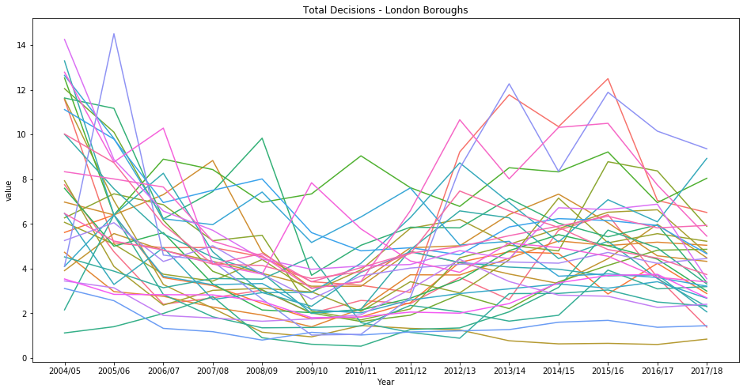

```python
fig = plt.figure(figsize=(16,8))
plt.title('Total Decisions - London Boroughs')
ax = sns.lineplot(x="Year", y="value", hue="Area name",legend=False,data=decisionsmelt)
```

It is difficult to see the trend of a single borough, but also to see how the trend of a given borough relates to other boroughs.

Therefore, we can produce a timeseries of each cluster to see how homelessness has changed in the London boroughs.

```python
decisionsmelt.to_csv('decisionscluster.csv')
```

We will export this to csv as we know the cluster numbers are meaningless. Therefore saving the csv will make sure any future work on groups keeps same numbers.

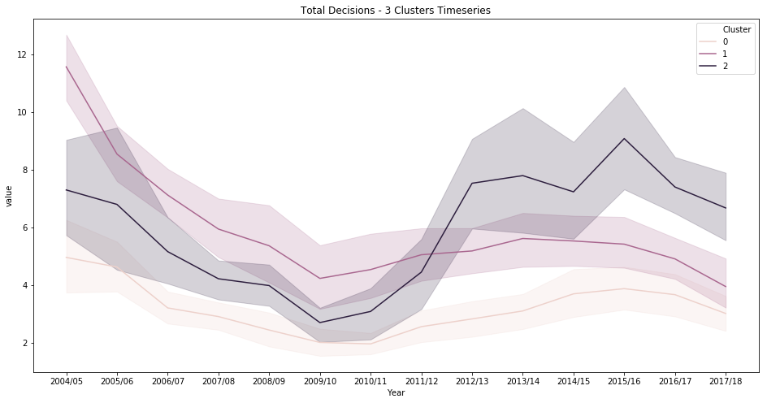

```python
fig = plt.figure(figsize=(16,8))
plt.title('Total Decisions - 3 Clusters Timeseries')
ax = sns.lineplot(x="Year", y="value", hue="Cluster",data=decisionsmelt)
```

We can clearly see there are 3 distinct clusters: low numbers of homeless, high but falling numbers of homeless and falling and recently increasing.

We can look at a timeseries for each cluster to evaluate the algorithm.

```python
#computing K-Means with K = 4 (4 clusters)
kmeansModel = KMeans(init='random', n_clusters=4, n_init=10)
kmeansModel.fit_predict(decisionscluster)
clusterResults4 = kmeansModel.labels_
clusterResults4
```

```
array([1, 2, 1, 3, 2, 3, 1, 2, 2, 2, 1, 2, 1, 1, 0, 3, 1, 1, 1, 3, 2, 1,
       1, 1, 0, 2, 2, 1, 2, 1, 2, 2, 1])
```

```python
decisions_with_mean['Cluster4'] = clusterResults4.tolist()
```

```python
#Drop first column
decisions_london = decisions_with_mean.iloc[:,1:]
decisionsmelt = decisions_london.melt(id_vars = ['Area name','Cluster4'], var_name = 'Year')
```

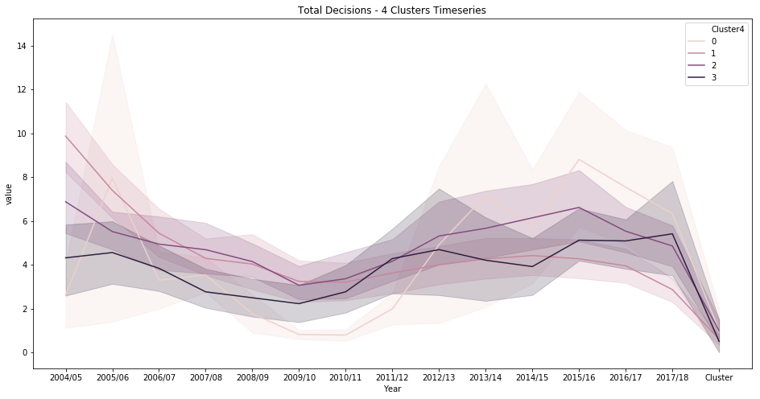

```python
fig = plt.figure(figsize=(16,8))
plt.title('Total Decisions - 4 Clusters Timeseries')
ax = sns.lineplot(x="Year", y="value", hue="Cluster4",data=decisionsmelt)
```

Cluster groups are much less visually accessible, therefore 3 clusters is the correct number for this analysis.

```python
# Let's load in our saved data:

decisionscluster = pd.read_csv('decisionscluster.csv')
decisionscluster
```

|  | Area name | Cluster | Year | value |
| --- | --- | --- | --- | --- |
| 0 | City of London | 0 | 2004/05 | 7.750000 |
| 1 | Barking and Dagenham | 2 | 2004/05 | 11.567164 |
| 2 | Barnet | 0 | 2004/05 | 5.614815 |
| 3 | Bexley | 0 | 2004/05 | 4.725275 |
| 4 | Brent | 1 | 2004/05 | 6.973684 |
| 5 | Bromley | 0 | 2004/05 | 3.906977 |
| 6 | Camden | 0 | 2004/05 | 11.595960 |
| 7 | Croydon | 2 | 2004/05 | 7.929577 |
| 8 | Ealing | 0 | 2004/05 | 6.069231 |
| 9 | Enfield | 2 | 2004/05 | 6.267241 |
| 10 | Greenwich | 1 | 2004/05 | 12.052083 |
| 11 | Hackney | 1 | 2004/05 | 12.532609 |
| 12 | Hammersmith and Fulham | 0 | 2004/05 | 7.593023 |
| 13 | Haringey | 1 | 2004/05 | 11.633663 |
| 14 | Harrow | 0 | 2004/05 | 1.116279 |
| 15 | Havering | 0 | 2004/05 | 2.150538 |
| 16 | Hillingdon | 0 | 2004/05 | 4.519608 |
| 17 | Hounslow | 1 | 2004/05 | 10.011236 |
| 18 | Islington | 1 | 2004/05 | 13.294118 |
| 19 | Kensington and Chelsea | 2 | 2004/05 | 6.472527 |
| 20 | Kingston upon Thames | 0 | 2004/05 | 4.093750 |
| 21 | Lambeth | 1 | 2004/05 | 12.646154 |
| 22 | Lewisham | 1 | 2004/05 | 11.116071 |
| 23 | Merton | 0 | 2004/05 | 3.107143 |
| 24 | Newham | 2 | 2004/05 | 4.102041 |
| 25 | Redbridge | 0 | 2004/05 | 5.252525 |
| 26 | Richmond upon Thames | 0 | 2004/05 | 3.444444 |
| 27 | Southwark | 1 | 2004/05 | 14.256410 |
| 28 | Sutton | 0 | 2004/05 | 3.532468 |
| 29 | Tower Hamlets | 1 | 2004/05 | 12.788889 |
| ... | ... | ... | ... | ... |
| 432 | Bexley | 0 | 2017/18 | 5.040000 |
| 433 | Brent | 1 | 2017/18 | 4.320000 |
| 434 | Bromley | 0 | 2017/18 | 4.480000 |
| 435 | Camden | 0 | 2017/18 | 0.840000 |
| 436 | Croydon | 2 | 2017/18 | 4.690000 |
| 437 | Ealing | 0 | 2017/18 | 5.220000 |
| 438 | Enfield | 2 | 2017/18 | 5.890000 |
| 439 | Greenwich | 1 | 2017/18 | 4.860000 |
| 440 | Hackney | 1 | 2017/18 | 8.040000 |
| 441 | Hammersmith and Fulham | 0 | 2017/18 | 2.990000 |
| 442 | Haringey | 1 | 2017/18 | 3.380000 |
| 443 | Harrow | 0 | 2017/18 | 3.310000 |
| 444 | Havering | 0 | 2017/18 | 3.190000 |
| 445 | Hillingdon | 0 | 2017/18 | 2.320000 |
| 446 | Hounslow | 1 | 2017/18 | 2.290000 |
| 447 | Islington | 1 | 2017/18 | 2.060000 |
| 448 | Kensington and Chelsea | 2 | 2017/18 | 8.930000 |
| 449 | Kingston upon Thames | 0 | 2017/18 | 2.670000 |
| 450 | Lambeth | 1 | 2017/18 | 3.210000 |
| 451 | Lewisham | 1 | 2017/18 | 4.660000 |
| 452 | Merton | 0 | 2017/18 | 1.440000 |
| 453 | Newham | 2 | 2017/18 | 9.360000 |
| 454 | Redbridge | 0 | 2017/18 | 4.450000 |
| 455 | Richmond upon Thames | 0 | 2017/18 | 2.400000 |
| 456 | Southwark | 1 | 2017/18 | 3.540000 |
| 457 | Sutton | 0 | 2017/18 | 2.690000 |
| 458 | Tower Hamlets | 1 | 2017/18 | 3.400000 |
| 459 | Waltham Forest | 2 | 2017/18 | 5.450000 |
| 460 | Wandsworth | 2 | 2017/18 | 5.930000 |
| 461 | Westminster | 1 | 2017/18 | 3.730000 |

462 rows × 4 columns

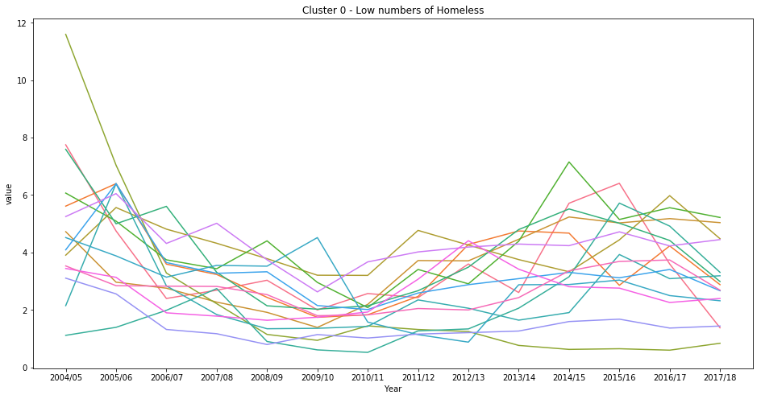

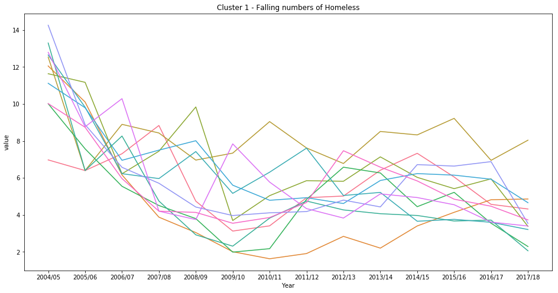

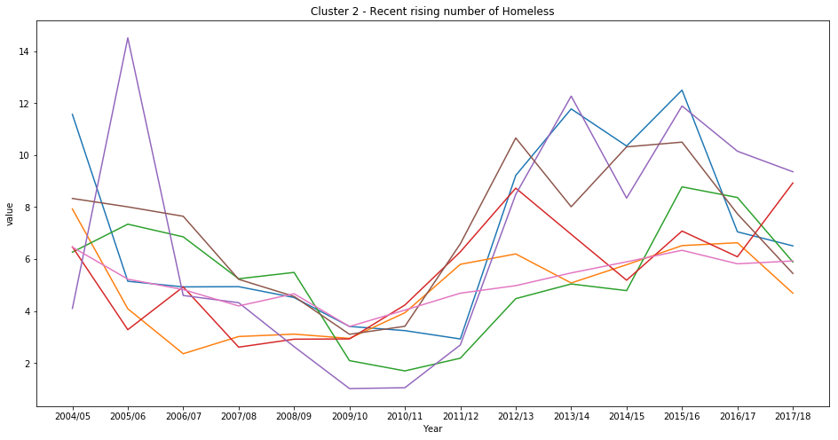

```python
import matplotlib.pyplot as plt
import seaborn as sns

cluster_0 = decisionscluster[decisionscluster['Cluster'] ==0]
cluster_1 = decisionscluster[decisionscluster['Cluster'] ==1]
cluster_2 = decisionscluster[decisionscluster['Cluster'] ==2]

fig = plt.figure(figsize=(16,8))
plt.figure(1)
plt.title('Cluster 0 - Low numbers of Homeless')
ax = sns.lineplot(x="Year", y="value",hue = 'Area name',legend=False,data=cluster_0)
fig = plt.figure(figsize=(16,8))
plt.figure(2)
plt.title('Cluster 1 - Falling numbers of Homeless')
ax1 = sns.lineplot(x="Year", y="value",hue = 'Area name',legend=False,data=cluster_1)
fig = plt.figure(figsize=(16,8))
plt.figure(3)
plt.title('Cluster 2 - Recent rising number of Homeless')
ax2 = sns.lineplot(x="Year", y="value",hue = 'Area name',legend=False,data=cluster_2)
```

We can see that in each cluster, there are boroughs that do not completely follow the trend. For example, within Cluster 0, the suggestion from the initial chart showing the cluster timeseries was that each of these boroughs showed the same trend (constant low number of homeless). However, we we look at each borough in this cluster as a timeseries, we can see that one borough starts much higher, and then dramatically falls, and could be thought to be included in the Cluster 1 (falling number of homeless).

To address this, we can look create a different feature which will describe the change in the number of homeless

```python
decisionscluster['pct_change_with_apply'] = decisionscluster.groupby('Area name')['value'].apply(lambda x: x.pct_change())
```

```python
decisionscluster
```

[output not shown]

462 rows × 6 columns

```python
#Let's drop the 2004 data so that we only have values and not NaNs
decisionspctchange = decisionscluster[decisionscluster['Year']!='2004/05']
decisionspctchange.head()
```

[output not shown]

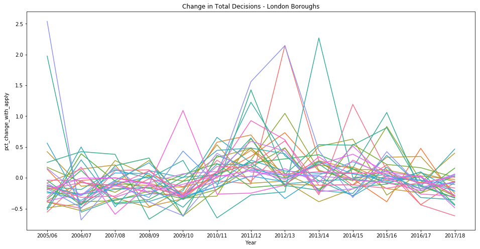

```python
fig = plt.figure(figsize=(16,8))
plt.title('Change in Total Decisions - London Boroughs')
ax = sns.lineplot(x="Year", y="pct_change_with_apply", hue="Area name",legend=False,data=decisionspctchange)
```

We can see that it is hard to identify any trends in the percent change year on year in the number of decisions. There are some more dramatic changes, but there seems to be not clear trend.

It may be more valuable to consider the change over a greater period of time.

```python
decisionschange = decisionscluster[(decisionscluster['Year']=='2004/05')|(decisionscluster['Year']=='2017/18')]
```

```python
decisionschange['pct_change_across_sample']=decisionschange.groupby('Area name')['value'].apply(lambda x: x.pct_change())
```

```python
decisionschangefilter = decisionschange[decisionschange['Year']!='2004/05']
decisionschangefilter.head()
```

|  | Area name | Cluster | Year | value | pctchange | pct_change_with_apply | pct_change_across_sample |
| --- | --- | --- | --- | --- | --- | --- | --- |
| 429 | City of London | 0 | 2017/18 | 1.38 | -0.767285 | -0.616667 | -0.821935 |
| 430 | Barking and Dagenham | 2 | 2017/18 | 6.51 | 3.717391 | -0.076596 | -0.437200 |
| 431 | Barnet | 0 | 2017/18 | 2.88 | -0.557604 | -0.319149 | -0.487071 |
| 432 | Bexley | 0 | 2017/18 | 5.04 | 0.750000 | -0.027027 | 0.066605 |
| 433 | Brent | 1 | 2017/18 | 4.32 | -0.142857 | -0.054705 | -0.380528 |

```
Text(0,0.5,'Decisions')
```

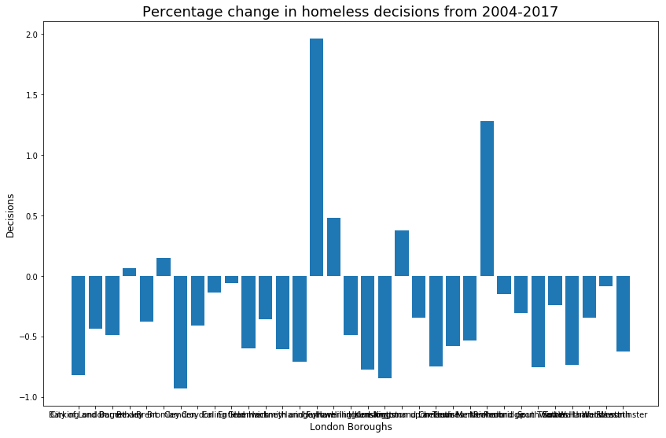

```python
fig = plt.figure(figsize=(14,9))
plt.bar(decisionschangefilter['Area name'],decisionschangefilter['pct_change_across_sample'])
plt.title('Percentage change in homeless decisions from 2004-2017', size = 18)
plt.xlabel('London Boroughs', size = 12)
plt.ylabel('Decisions', size = 12)
```

The chart is particularly difficult to read, due to the number of London Boroughs. However, the main limitation of this analysis is that we lose the majority of information, as there may be little change between the values for 2004 & 2017, but we do not account for the changes in the middle.

## Using government spend data to assess the impact on the number of roughsleepers

```python
data = pd.ExcelFile("roughsleeping.xlsx")
roughsleeptotal = data.parse("table 1")
```

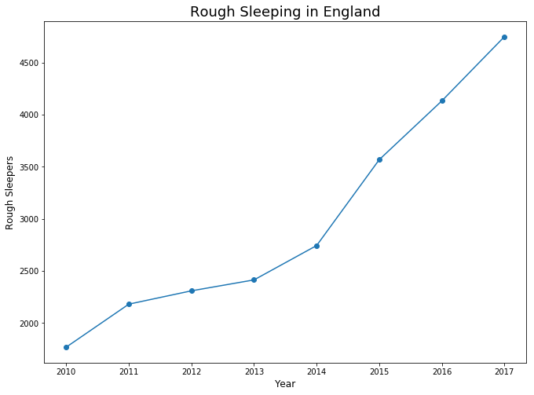

```python
select = roughsleeptotal.iloc[4,3:11]
engroughsleep = np.asarray(select)
import matplotlib.pyplot as plt

fig = plt.figure(figsize=(11,8))

year = np.array([2010,2011,2012,2013,2014,2015,2016,2017])

line_chart1 = plt.plot(year,engroughsleep, marker = 'o')
plt.title('Rough Sleeping in England', size = 18)
plt.xlabel('Year', size = 12)
plt.ylabel('Rough Sleepers', size = 12)
plt.show()
```

To make more accurate assessments of the impact of government spending on roughsleeping, it is important to find more years to see the trend over time.

```python
data = pd.ExcelFile("roughsleeping1998.xlsx")
roughsleep1998 = data.parse("Previous data")
# The total number of rough sleepers is in 1 row, which is in reversed order
dataimport = roughsleep1998.iloc[358,1:]
roughsleep98 = np.array(dataimport[::-1])
roughsleeptotal = np.append(roughsleep98,engroughsleep)
roughsleeptotal
```

```
array([1850.0, 1633.0, 1180.0, 681, 585, 493, 508, 459, 502, 498, 483,
       464, 1768, 2181.0, 2309.0, 2414.0, 2744.0, 3569.0, 4134.0, 4751.0],
      dtype=object)
```

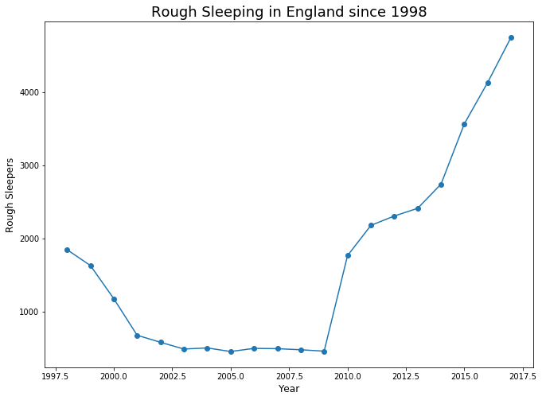

```python
fig = plt.figure(figsize=(11,8))

year = np.array([1998,1999,2000,2001,2002,2003,2004,2005,2006,2007,2008,2009,2010,2011,2012,2013,2014,2015,2016,2017])

line_chart1 = plt.plot(year,roughsleeptotal, marker = 'o')
plt.title('Rough Sleeping in England since 1998', size = 18)
plt.xlabel('Year', size = 12)
plt.ylabel('Rough Sleepers', size = 12)
plt.show()
```

Government spending data is publicly available. We can see the amount spent in each general area, from 1998 to today. The data is from data.gov.

```python
## Adding contextual factors to assess what may contribute to roughsleeping:

spending = pd.ExcelFile("PESA_2017.xlsx")
spending = spending.parse("4.3")
print(spending.head())
```

```
  Table 4.3 Public sector expenditure on services by function in real terms(1), 1993-94 to 2016-17  \
0                                                NaN
1                                                NaN
2                                                NaN
3                                                NaN
4                                                NaN

   Unnamed: 1 Unnamed: 2 Unnamed: 3 Unnamed: 4 Unnamed: 5      Unnamed: 6  \
0         NaN        NaN        NaN        NaN        NaN             NaN
1  cash basis        NaN        NaN        NaN        NaN  accruals basis
2         NaN        NaN        NaN        NaN        NaN             NaN
3     1993-94    1994-95    1995-96    1996-97    1997-98         1998-99
4     outturn    outturn    outturn    outturn    outturn         outturn

  Unnamed: 7           Unnamed: 8 Unnamed: 9     ...     Unnamed: 15  \
```

[output cut: 21 more lines]

```python
#Create array for each row of interest to make new dataframe

social_protection = spending.iloc[22,5:]
housing = spending.iloc[18,5:]
health = spending.iloc[19,5:]

social_protection_array = np.asarray(social_protection)
housing_array = np.asarray(housing)
health_array = np.asarray(health)

housing_array
```

```
array([7, 7.7, 6.6, 7.5, 8.4, 7.1, 8.7, 10.1, 13.1, 13.7, 15.1, 17.3,
       18.2, 14.6, 11, 10.7, 10.4, 10.7, 10.2, 10.6], dtype=object)
```

```python
data = pd.DataFrame({'social_protection':social_protection_array, 'housing':housing_array, 'health':health_array, 'roughsleepers': roughsleeptotal})
data
```

|  | social_protection | housing | health | roughsleepers |
| --- | --- | --- | --- | --- |
| 0 | 163.1 | 7 | 63.4 | 1850 |
| 1 | 161.8 | 7.7 | 65.9 | 1633 |
| 2 | 171.9 | 6.6 | 69 | 1180 |
| 3 | 176 | 7.5 | 74.2 | 681 |
| 4 | 185.8 | 8.4 | 80.9 | 585 |
| 5 | 192.1 | 7.1 | 87.5 | 493 |
| 6 | 201.2 | 8.7 | 96.9 | 508 |
| 7 | 206.7 | 10.1 | 104.4 | 459 |
| 8 | 209.8 | 13.1 | 110.2 | 502 |
| 9 | 210.8 | 13.7 | 112.8 | 498 |
| 10 | 219.3 | 15.1 | 117.5 | 483 |
| 11 | 230.2 | 17.3 | 123 | 464 |
| 12 | 249 | 18.2 | 130.5 | 1768 |
| 13 | 252.6 | 14.6 | 131.5 | 2181 |
| 14 | 264.8 | 11 | 131.1 | 2309 |
| 15 | 268.5 | 10.7 | 131.7 | 2414 |
| 16 | 264.6 | 10.4 | 134.8 | 2744 |
| 17 | 267.9 | 10.7 | 137.7 | 3569 |
| 18 | 270.3 | 10.2 | 141.3 | 4134 |
| 19 | 264.3 | 10.6 | 144.3 | 4751 |

In order to make sure that population is not a factor in assessing the changes in roughsleepers, we can normalise for number of households in the UK.

```python
house = pd.ExcelFile("households.xlsx")
households = house.parse("Final")
enghouseholds = households.iloc[20,3:]
enghouseholdsarray = np.asarray(enghouseholds)
print(enghouseholdsarray)
```

```
[20056900.0 20191500.0 20331400 20416200.0 20685300.0 20780900.0
 20820500.0 21036500.0 21211500.0 21348800.0 21589000.0 21716400.0
 21867000.0 22068700.0 22171600.0 22209300.0 22292200.0 22583600.0
 22623400.0 22694600.0]
```

```python
datanorm = pd.DataFrame({'social_protection':social_protection_array, 'housing':housing_array, 'health':health_array, 'roughsleepers': roughsleeptotal, 'enghouseholds':enghouseholdsarray})
datanorm['enghouseholds/10000'] = datanorm['enghouseholds']/10000
datanorm['roughsleepersper10000households'] = datanorm['roughsleepers']/datanorm['enghouseholds/10000']
datanorm
```

|  | social_protection | housing | health | roughsleepers | enghouseholds | enghouseholds/10000 | roughsleepersper10000households |
| --- | --- | --- | --- | --- | --- | --- | --- |
| 0 | 163.1 | 7 | 63.4 | 1850 | 2.00569e+07 | 2005.69 | 0.922376 |
| 1 | 161.8 | 7.7 | 65.9 | 1633 | 2.01915e+07 | 2019.15 | 0.808756 |
| 2 | 171.9 | 6.6 | 69 | 1180 | 20331400 | 2033.14 | 0.580383 |
| 3 | 176 | 7.5 | 74.2 | 681 | 2.04162e+07 | 2041.62 | 0.333559 |
| 4 | 185.8 | 8.4 | 80.9 | 585 | 2.06853e+07 | 2068.53 | 0.28281 |
| 5 | 192.1 | 7.1 | 87.5 | 493 | 2.07809e+07 | 2078.09 | 0.237237 |
| 6 | 201.2 | 8.7 | 96.9 | 508 | 2.08205e+07 | 2082.05 | 0.24399 |
| 7 | 206.7 | 10.1 | 104.4 | 459 | 2.10365e+07 | 2103.65 | 0.218192 |
| 8 | 209.8 | 13.1 | 110.2 | 502 | 2.12115e+07 | 2121.15 | 0.236664 |
| 9 | 210.8 | 13.7 | 112.8 | 498 | 2.13488e+07 | 2134.88 | 0.233268 |
| 10 | 219.3 | 15.1 | 117.5 | 483 | 2.1589e+07 | 2158.9 | 0.223725 |
| 11 | 230.2 | 17.3 | 123 | 464 | 2.17164e+07 | 2171.64 | 0.213663 |
| 12 | 249 | 18.2 | 130.5 | 1768 | 2.1867e+07 | 2186.7 | 0.808524 |
| 13 | 252.6 | 14.6 | 131.5 | 2181 | 2.20687e+07 | 2206.87 | 0.988278 |
| 14 | 264.8 | 11 | 131.1 | 2309 | 2.21716e+07 | 2217.16 | 1.04142 |
| 15 | 268.5 | 10.7 | 131.7 | 2414 | 2.22093e+07 | 2220.93 | 1.08693 |
| 16 | 264.6 | 10.4 | 134.8 | 2744 | 2.22922e+07 | 2229.22 | 1.23092 |
| 17 | 267.9 | 10.7 | 137.7 | 3569 | 2.25836e+07 | 2258.36 | 1.58035 |
| 18 | 270.3 | 10.2 | 141.3 | 4134 | 2.26234e+07 | 2262.34 | 1.82731 |
| 19 | 264.3 | 10.6 | 144.3 | 4751 | 2.26946e+07 | 2269.46 | 2.09345 |

```
Text(0.5,0,'Housing Spending (£m)')
```

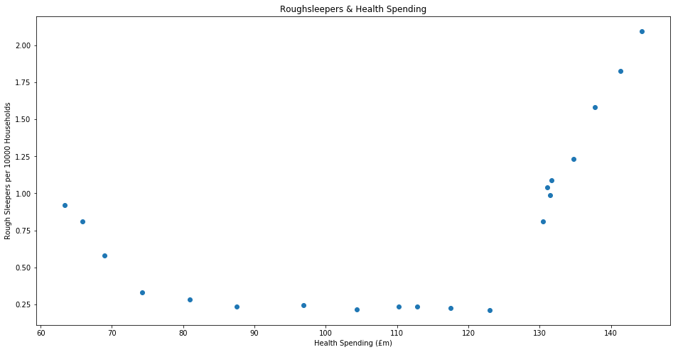

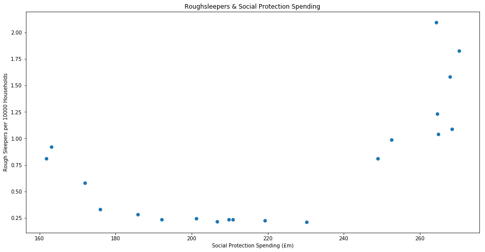

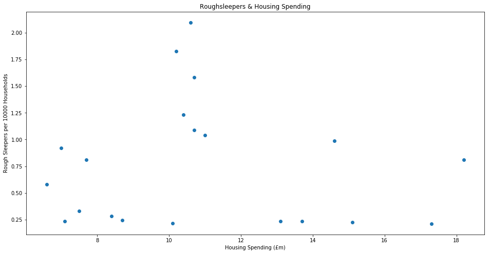

```python
fig = plt.figure(figsize=(16,8))
plt.figure(1)
plt.title('Roughsleepers & Health Spending')
plt.scatter(datanorm['health'],datanorm['roughsleepersper10000households'])
plt.xlabel('Health Spending (£m)')
plt.ylabel('Rough Sleepers per 10000 Households')
fig = plt.figure(figsize=(16,8))
plt.figure(2)
plt.title('Roughsleepers & Social Protection Spending')
plt.scatter(datanorm['social_protection'],datanorm['roughsleepersper10000households'])
plt.xlabel('Social Protection Spending (£m)')
plt.ylabel('Rough Sleepers per 10000 Households')
fig = plt.figure(figsize=(16,8))
plt.figure(3)
plt.title('Roughsleepers & Housing Spending')
plt.scatter(datanorm['housing'],datanorm['roughsleepersper10000households'])
plt.ylabel('Rough Sleepers per 10000 Households')
plt.xlabel('Housing Spending (£m)')
```

Finally, we can also hypothesise that the average real earnings of a person in the UK may have an impact on the number of homeless and roughsleepers.

## Real earnings and homelessness

```python
realearnings = pd.read_csv('avgweekearnings.csv')
realearnings.head()
```

|  | Period | Regular pay | Total pay |
| --- | --- | --- | --- |
| 0 | Mar-06 | 1.8 | 3.2 |
| 1 | Apr-06 | 1.7 | 3.3 |
| 2 | May-06 | 1.6 | 2.6 |
| 3 | Jun-06 | 1.6 | 2.2 |
| 4 | Jul-06 | 1.4 | 2.3 |

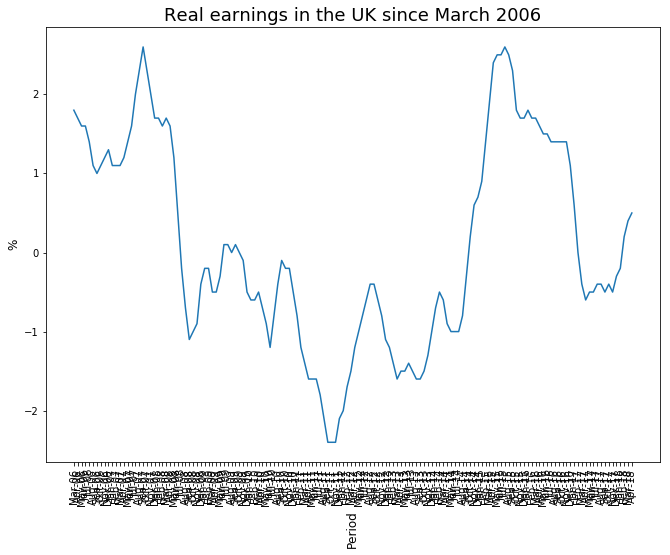

```python
fig = plt.figure(figsize=(11,8))
line_chart1 = plt.plot(realearnings['Period'],realearnings['Regular pay'])
plt.title('Real earnings in the UK since March 2006', size = 18)
plt.xlabel('Period', size = 12,rotation='vertical')
plt.ylabel('%', size = 12)
_=plt.xticks(rotation=90)
plt.show()
```

```python
realearningsdate = pd.to_datetime(realearnings['Period'], format='%b-%y')
date = np.array(realearningsdate)
realearnings['date'] = date
```

```python
realearnings.head()
```

|  | Period | Regular pay | Total pay | date |
| --- | --- | --- | --- | --- |
| 0 | Mar-06 | 1.8 | 3.2 | 2006-03-01 |
| 1 | Apr-06 | 1.7 | 3.3 | 2006-04-01 |
| 2 | May-06 | 1.6 | 2.6 | 2006-05-01 |
| 3 | Jun-06 | 1.6 | 2.2 | 2006-06-01 |
| 4 | Jul-06 | 1.4 | 2.3 | 2006-07-01 |

```python
#We can group by year to get the average real wage per year
```

```python
realearningsyear = realearnings.groupby(realearnings.date.dt.year)['Regular pay'].mean()
```

```python
realearningsyeardf = pd.DataFrame(realearningsyear)
realearningsyeardf['year'] = realearningsyeardf.index
realearningsyeardf
```

| date | Regular pay | year |
| --- | --- | --- |
| 2006 | 1.380000 | 2006 |
| 2007 | 1.700000 | 2007 |
| 2008 | 0.333333 | 2008 |
| 2009 | -0.166667 | 2009 |
| 2010 | -0.558333 | 2010 |
| 2011 | -1.783333 | 2011 |
| 2012 | -1.008333 | 2012 |
| 2013 | -1.425000 | 2013 |
| 2014 | -0.441667 | 2014 |
| 2015 | 2.016667 | 2015 |
| 2016 | 1.491667 | 2016 |
| 2017 | -0.325000 | 2017 |
| 2018 | 0.225000 | 2018 |

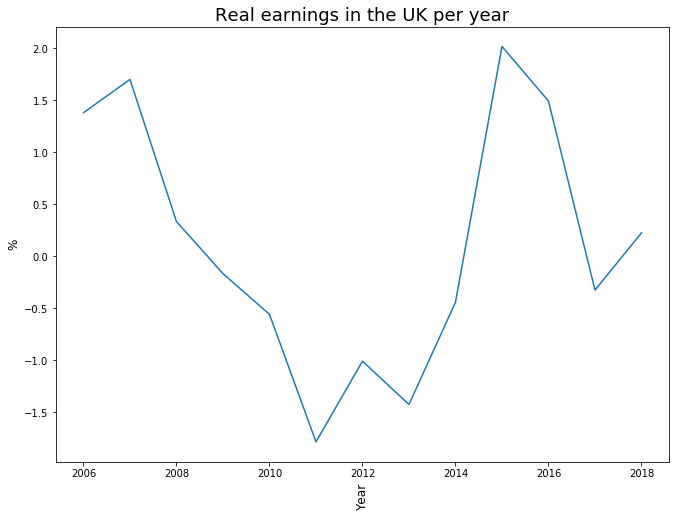

```python
fig = plt.figure(figsize=(11,8))
line_chart1 = plt.plot(realearningsyeardf['year'],realearningsyeardf['Regular pay'])
plt.title('Real earnings in the UK per year', size = 18)
plt.xlabel('Year', size = 12,rotation='vertical')
plt.ylabel('%', size = 12)
plt.show()
```

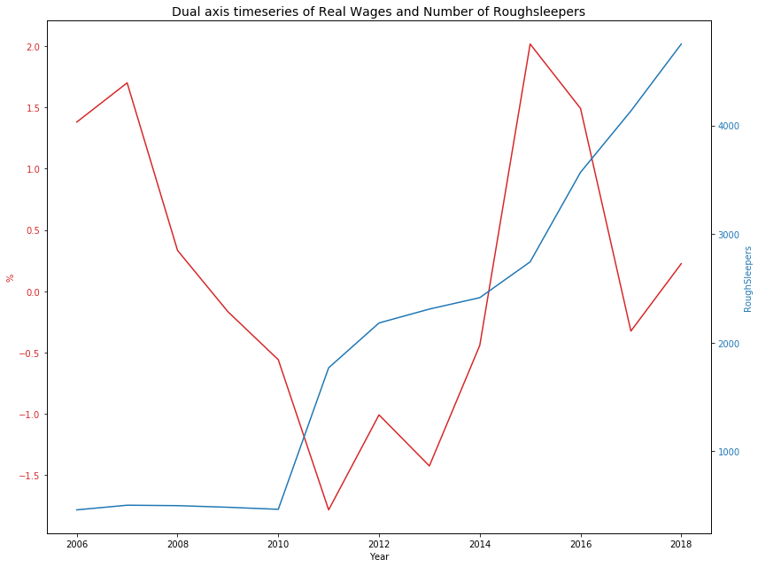

```python
#Create a dual axis chart to look at both timeseries (roughsleepers and real wages)
fig, ax1 = plt.subplots(figsize=(12, 9))
plt.title('Dual axis timeseries of Real Wages and Number of Roughsleepers',size=14)

color = 'tab:red'
ax1.set_xlabel('Year')
ax1.set_ylabel('%', color=color)
ax1.plot(realearningsyeardf['year'],realearningsyeardf['Regular pay'],color=color)
ax1.tick_params(axis='y', labelcolor=color)

ax2 = ax1.twinx()

roughsleeparray = roughsleeptotal[7:20]

color = 'tab:blue'
ax2.set_ylabel('RoughSleepers', color=color)  # we already handled the x-label with ax1
ax2.plot(realearningsyeardf['year'], roughsleeparray, color=color)
ax2.tick_params(axis='y', labelcolor=color)

fig.tight_layout()  # otherwise the right y-label is slightly clipped
plt.show()
```

Looking at the chart, we can clearly see that as real wages fall from 2006-2011, roughsleeper numbers start to increase in 2010. We can hypothesise that the impact of falling real wages may not have an immediate impact on the number of roughsleepers, but the impact that continued decline in real wages may have on spending, and therefore business revenue. Many people may face losing their jobs over this time, which can lead into a decent into homelessness and sleeping rough.

It is difficult to assess the correlation between real wages and roughsleeping, especially as roughsleeping continues to rise with the increase in real wages between 2013-2015. However, much of the damage may have been done during the dramatic fall in real wages from 2006-2011.